# Pr0-Remostreig

Enola Garcia Carbó NIU: 1708253

2026-02-19

# QÜESTIÓ 1

**1. Estadística descriptiva de les dades. Modificar errors**

```r
library(readxl)
data <- read_excel("dades_ratio_dits_Remostreig_2022-23.xlsx")
data$sexe <- as.factor(data$sexe)
data$Curs <- as.factor(data$Curs)
data$parella <- as.factor(data$parella)
summary(data)
```

```
##        ID            Curs      sexe        altura          polze
##  Min.   : 1.0   2021-22:41   d   :27   Min.   :153.0   Min.   :45.00
##  1st Qu.:15.5   2022-23:18   h   :29   1st Qu.:167.0   1st Qu.:56.00
##  Median :30.0                NA's: 3   Median :172.0   Median :60.00
##  Mean   :30.0                          Mean   :172.2   Mean   :60.29
##  3rd Qu.:44.5                          3rd Qu.:178.0   3rd Qu.:65.00
##  Max.   :59.0                          Max.   :190.0   Max.   :76.00
##                                        NA's   :1
##      index             mig             anular           menut
##  Min.   : 62.00   Min.   : 70.00   Min.   : 65.00   Min.   : 6.00
##  1st Qu.: 77.00   1st Qu.: 82.50   1st Qu.: 74.50   1st Qu.:60.00
##  Median : 82.00   Median : 90.00   Median : 83.00   Median :65.00
##  Mean   : 81.64   Mean   : 90.53   Mean   : 82.86   Mean   :65.27
##  3rd Qu.: 86.50   3rd Qu.: 97.00   3rd Qu.: 90.00   3rd Qu.:72.00
##  Max.   :101.00   Max.   :113.00   Max.   :107.00   Max.   :87.00
##
##    punt_pare       punt_mare      parella    punt_parella
##  Min.   :10.00   Min.   : 25.00   no  :22   Min.   : 70.00
##  1st Qu.:70.00   1st Qu.: 72.50   NO  : 2   1st Qu.: 90.00
##  Median :80.00   Median : 85.00   si  :33   Median : 95.00
##  Mean   :75.47   Mean   : 79.85   NA's: 2   Mean   : 91.27
##  3rd Qu.:90.00   3rd Qu.: 90.00             3rd Qu.: 95.00
##  Max.   :98.00   Max.   :100.00             Max.   :100.00
##  NA's   :2                                  NA's   :26
##  sensacio_periode_covid
##  Min.   :10.00
##  1st Qu.:50.00
##  Median :70.00
##  Mean   :63.88
##  3rd Qu.:80.00
##  Max.   :95.00
##
```

Considerem eliminar la observació 4, ja que per una banda té valor perdut a `Sexe` i 6 a `menut`, que s’allunya molt de la mitjana. Com no sabem quin valor és realment, l’eliminem

```r
data[4,]
```

```
## # A tibble: 1 × 14
##      ID Curs    sexe  altura polze index   mig anular menut punt_pare punt_mare
##   <dbl> <fct>   <fct>  <dbl> <dbl> <dbl> <dbl>  <dbl> <dbl>     <dbl>     <dbl>
## 1     4 2021-22 <NA>     185    65    85    97     85     6        90        85
## # ℹ 3 more variables: parella <fct>, punt_parella <dbl>,
## #   sensacio_periode_covid <dbl>
```

```r
data <- data[-4,]
```

Per altra banda, observem que a la variable `parella` hi ha valors en majúscules i minúscules, ho corregim passant-los tot a minúscules:

```r
data$parella <- tolower(data$parella)
data$parella <- as.factor(data$parella)
```

Tornem a observar el summary() i apareixen 2 NA’s a la variable `Sexe`, com més endavant volem comparar homes i dones, si ho deixem poden suposar un problema. Per aquest motiu, eliminem aquestes dues observacions, ja que és un número reduït de files

```r
summary(data)
```

```
##        ID             Curs      sexe        altura        polze
##  Min.   : 1.00   2021-22:40   d   :27   Min.   :153   Min.   :45.00
##  1st Qu.:16.25   2022-23:18   h   :29   1st Qu.:167   1st Qu.:56.00
##  Median :30.50                NA's: 2   Median :171   Median :60.00
##  Mean   :30.45                          Mean   :172   Mean   :60.21
##  3rd Qu.:44.75                          3rd Qu.:178   3rd Qu.:64.75
##  Max.   :59.00                          Max.   :190   Max.   :76.00
##                                         NA's   :1
##      index             mig             anular           menut
##  Min.   : 62.00   Min.   : 70.00   Min.   : 65.00   Min.   :54.00
##  1st Qu.: 77.00   1st Qu.: 82.25   1st Qu.: 74.25   1st Qu.:60.00
##  Median : 81.50   Median : 90.00   Median : 82.50   Median :65.00
##  Mean   : 81.59   Mean   : 90.41   Mean   : 82.83   Mean   :66.29
##  3rd Qu.: 86.75   3rd Qu.: 97.00   3rd Qu.: 90.00   3rd Qu.:72.00
##  Max.   :101.00   Max.   :113.00   Max.   :107.00   Max.   :87.00
##
##    punt_pare       punt_mare      parella    punt_parella
##  Min.   :10.00   Min.   : 25.00   no  :24   Min.   : 70.00
##  1st Qu.:70.00   1st Qu.: 71.25   si  :32   1st Qu.: 90.00
##  Median :80.00   Median : 85.00   NA's: 2   Median : 92.50
##  Mean   :75.21   Mean   : 79.76             Mean   : 91.16
##  3rd Qu.:90.00   3rd Qu.: 90.00             3rd Qu.: 95.00
##  Max.   :98.00   Max.   :100.00             Max.   :100.00
##  NA's   :2                                  NA's   :26
##  sensacio_periode_covid
##  Min.   :10.00
##  1st Qu.:50.00
##  Median :70.00
##  Mean   :64.03
##  3rd Qu.:80.00
##  Max.   :95.00
##
```

```r
data <- data[-c(4,55),]
```

**2. Convertim les puntuacions a escala 0-10 i les mesures de dits en centímetres**

```r
# Puntuacions a escala 0-10
data$punt_pare <- data$punt_pare / 10
data$punt_mare <- data$punt_mare / 10
data$punt_parella <- data$punt_parella / 10
data$sensacio_periode_covid <- data$sensacio_periode_covid / 10

# Mesures dels dits a centímetres (actualment en mm)
data$polze <- data$polze / 10
data$index <- data$index / 10
data$mig <- data$mig / 10
data$anular <- data$anular / 10
data$menut <- data$menut / 10

summary(data)
```

```
##        ID             Curs    sexe       altura          polze
##  Min.   : 1.00   2021-22:39   d:27   Min.   :153.0   Min.   :4.500
##  1st Qu.:16.75   2022-23:17   h:29   1st Qu.:166.5   1st Qu.:5.600
##  Median :30.50                       Median :171.0   Median :6.000
##  Mean   :30.45                       Mean   :171.9   Mean   :6.039
##  3rd Qu.:44.25                       3rd Qu.:178.0   3rd Qu.:6.500
##  Max.   :59.00                       Max.   :190.0   Max.   :7.600
##
##      index             mig             anular           menut
##  Min.   : 6.200   Min.   : 7.000   Min.   : 6.500   Min.   :5.400
##  1st Qu.: 7.650   1st Qu.: 8.200   1st Qu.: 7.400   1st Qu.:6.000
##  Median : 8.100   Median : 9.000   Median : 8.250   Median :6.500
##  Mean   : 8.143   Mean   : 9.034   Mean   : 8.284   Mean   :6.616
##  3rd Qu.: 8.650   3rd Qu.: 9.700   3rd Qu.: 9.025   3rd Qu.:7.200
##  Max.   :10.100   Max.   :11.300   Max.   :10.700   Max.   :8.700
##
##    punt_pare       punt_mare      parella    punt_parella
##  Min.   :1.000   Min.   : 2.500   no  :24   Min.   : 7.000
##  1st Qu.:7.000   1st Qu.: 7.375   si  :30   1st Qu.: 9.000
##  Median :8.000   Median : 8.500   NA's: 2   Median : 9.250
##  Mean   :7.504   Mean   : 7.975             Mean   : 9.107
##  3rd Qu.:9.000   3rd Qu.: 9.000             3rd Qu.: 9.500
##  Max.   :9.800   Max.   :10.000             Max.   :10.000
##  NA's   :2                                  NA's   :26
##  sensacio_periode_covid
##  Min.   :1.000
##  1st Qu.:5.000
##  Median :7.000
##  Mean   :6.329
##  3rd Qu.:7.625
##  Max.   :9.500
##
```

**3. Fem un corrplot per a les variables numèriques de la base de dades**

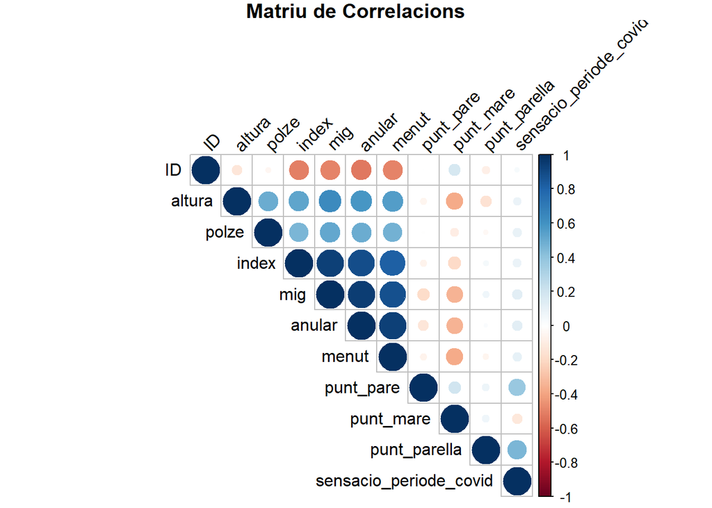

```r
library(corrplot)
# variables numèriques (excloem ID)
data_num <- data[, sapply(data, is.numeric)]

# matriu de correlació
corr <- cor(data_num, use = "complete.obs")

corrplot(corr, method = "circle", type = "upper",
         tl.col = "black",tl.srt = 45,
         title = "Matriu de Correlacions", mar=c(0,0,1,0))
```

**4. Calculem la matriu de correlacions dels dits de la mà.**

```r
dits <- data[, c("polze", "index", "mig", "anular", "menut")]
cor(dits, use = "complete.obs")
```

```
##            polze     index       mig    anular     menut
## polze  1.0000000 0.6204182 0.6326381 0.5822493 0.5724384
## index  0.6204182 1.0000000 0.9451309 0.8772188 0.8445745
## mig    0.6326381 0.9451309 1.0000000 0.9398543 0.9027651
## anular 0.5822493 0.8772188 0.9398543 1.0000000 0.9320610
## menut  0.5724384 0.8445745 0.9027651 0.9320610 1.0000000
```

Els dits més correlacionats són el **mig i l’index** amb una correlació positiva de 0.945, seguits de l’**anular i el mig** amb 0.939, ja que les estructures òssies són similars.

Els dits menys correlacionats són el **polze i el menut** amb correlació de 0.572. El polze és el dit amb menys correlació amb la resta, ja que té una funció i estructura més diferenciada de la resta.

**5. Calculem la variable 2D: 4D ratio dels dits. Fem una descripció i calculem els percentils 25%, 50% (mediana) i 75%. Fem un histograma de la variable**

L’estudi de Bailey i Hurd suggereix que la ràtio entre el segon dit (índex) i el quart (anular) és un indicador de trets biològics.

```r
# Calculem la ràtio
data$ratio_2D4D <- data$index / data$anular

# Percentils
quantile(data$ratio_2D4D, probs = c(0.25, 0.5, 0.75), na.rm = TRUE)
```

```
##       25%       50%       75%
## 0.9333333 0.9877259 1.0271429
```

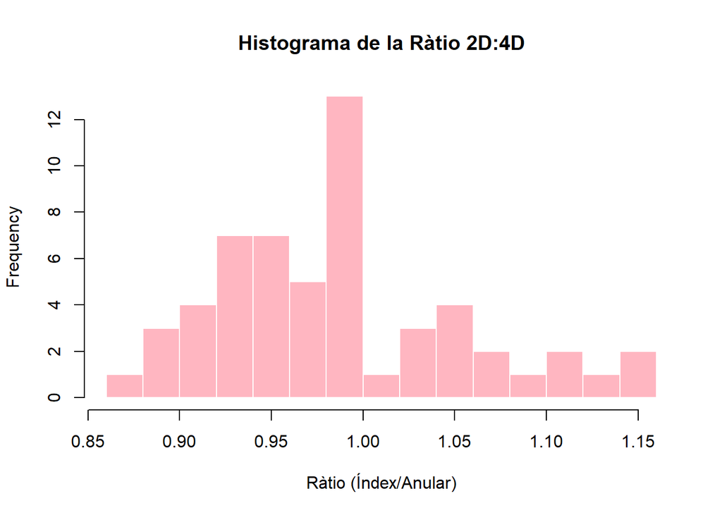

```r
# Histograma
hist(data$ratio_2D4D, main = "Histograma de la Ràtio 2D:4D",
     xlab = "Ràtio (Índex/Anular)", col = "lightpink", border = "white", breaks = 10)
```

La ràtio mitjana se situa al voltant de $0.987$. El percentil $50$ (mediana) ens indica que la meitat de la mostra té una ràtio inferior a $0.988$.

**6. Comparem els valors d’aquesta variable segons homes i dones**

```r
# Comparació de mitjanes
aggregate(ratio_2D4D ~ `sexe`, data = data, FUN = mean)
```

```
##   sexe ratio_2D4D
## 1    d  0.9932796
## 2    h  0.9821196
```

```r
t.test(ratio_2D4D ~ `sexe`, data = data)
```

```
##
##  Welch Two Sample t-test
##
## data:  ratio_2D4D by sexe
## t = 0.62732, df = 53.143, p-value = 0.5331
## alternative hypothesis: true difference in means between group d and group h is not equal to 0
## 95 percent confidence interval:
##  -0.02451987  0.04683976
## sample estimates:
## mean in group d mean in group h
##       0.9932796       0.9821196
```

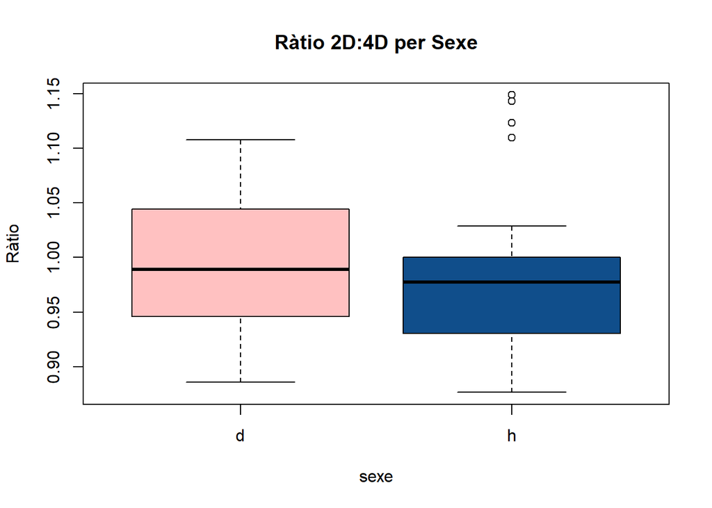

```r
# Visualització
boxplot(ratio_2D4D ~ `sexe`, data = data,
        main = "Ràtio 2D:4D per Sexe",
        col = c("rosybrown1", "dodgerblue4"),
        ylab = "Ràtio")
```

Segons l’article, els homes tenen una ràtio 2D:4D més baixa que les dones, és a dir, el dit anular (4) és proporcionalment més llarg que el índex (2).

Per les nostres dades, les dones `d` mostren una mitjana lleugerament superior que els homes `h`, la qual cosa és coherent amb la literatura científica, però segons el test, aquesta diferència no és significativa.

**7. Testem la hipòtesi de l’article amb les dades de la mostra, correlacionant el seu valor amb les diferents puntuacions obtingudes**

```r
#Separem en homes i dones
data_homes=subset(data, `sexe`=="h")
data_dones=subset(data, `sexe`=="d")

cor(data_homes$ratio_2D4D, data_homes[, c("punt_pare", "punt_mare", "punt_parella")], use = "pairwise.complete.obs")
```

```
##        punt_pare punt_mare punt_parella
## [1,] -0.04935672 0.2413257    0.4403083
```

```r
cor(data_dones$ratio_2D4D, data_dones[, c("punt_pare", "punt_mare", "punt_parella")], use = "pairwise.complete.obs")
```

```
##      punt_pare punt_mare punt_parella
## [1,] 0.2147807 0.1560192  -0.08489055
```

S’ha separat el dataset en homes i dones, ja que l’article diu que el comportament canvia segons el sexe.

Com podem veure a l’output de les correlacions, en primer lloc, no hi ha cap correlació elevada entre la variable ratio i les de puntuació, únicament una mica el del ratio dels homes i la puntuació de parella, però, aquest valor no és preocupant, també, observant els valors entre homes i dones, aquests, presenten diferencies, però no tot en contra dels homes, ja que en puntuació del pare, les dones estan molt més correlacionades que els homes, a la puntuació de la mare, els homes estan una mica per sobre i és a la puntuació de parella on els homes estan realment més correlacionades als homes.

**8. Ajustem un model lineal amb les puntuacions del pare i la mare.**

```r
model_pares <- lm(punt_mare ~ punt_pare, data = data)

summary(model_pares)
```

```
##
## Call:
## lm(formula = punt_mare ~ punt_pare, data = data)
##
## Residuals:
##     Min      1Q  Median      3Q     Max
## -5.6414 -0.4412  0.5588  0.9089  2.0579
##
## Coefficients:
##             Estimate Std. Error t value Pr(>|t|)
## (Intercept)   5.7428     0.8411   6.828 9.32e-09 ***
## punt_pare     0.2998     0.1083   2.768   0.0078 **
## ---
## Signif. codes:  0 '***' 0.001 '**' 0.01 '*' 0.05 '.' 0.1 ' ' 1
##
## Residual standard error: 1.591 on 52 degrees of freedom
##   (2 observations deleted due to missingness)
## Multiple R-squared:  0.1284, Adjusted R-squared:  0.1117
## F-statistic: 7.662 on 1 and 52 DF,  p-value: 0.007796
```

Els paràmetres del model són:

- $\beta_0=5.7428$ és el valor teòric de la puntuació amb la mare si la puntuació amb el pare és zero
- $\beta_1=0.2998$: per cada punt que augmenta la relació amb el pare, la relació amb la mare augmenta, de mitjana, 0.3 punts aproximadament. Aquesta relació és estadísticament significativa (pvalor<0.05)

Per altra, el $R^2=1284$, això vol dir que la puntuació del pare només explica un 12.8% de la variabilitat de la puntuació de la mare. La resta (87.2%) depèn d’altres factors no inclosos en aquest model.

**9. Fem un diagnòstic dels residus del model**

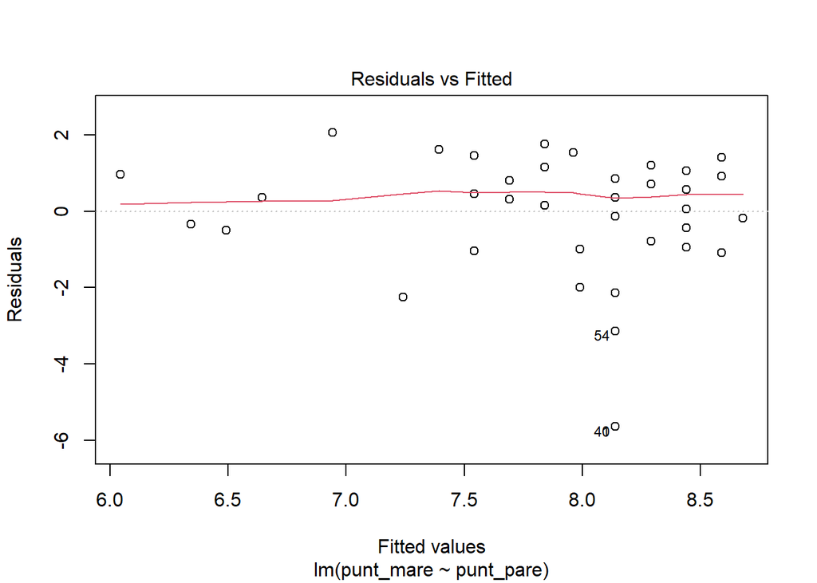

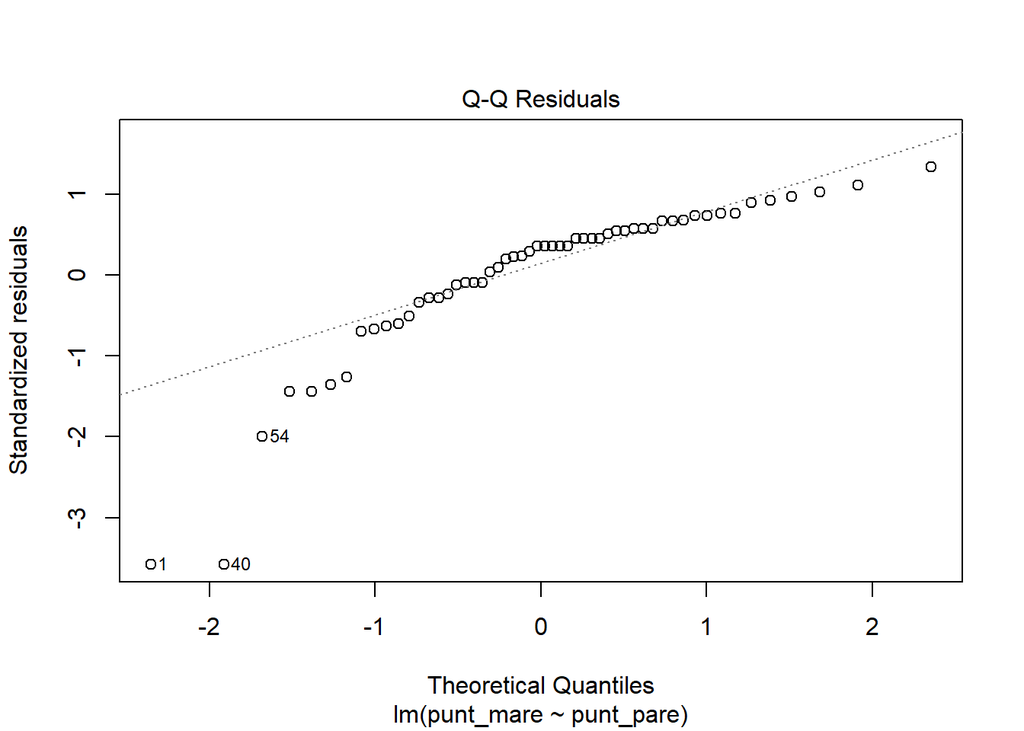

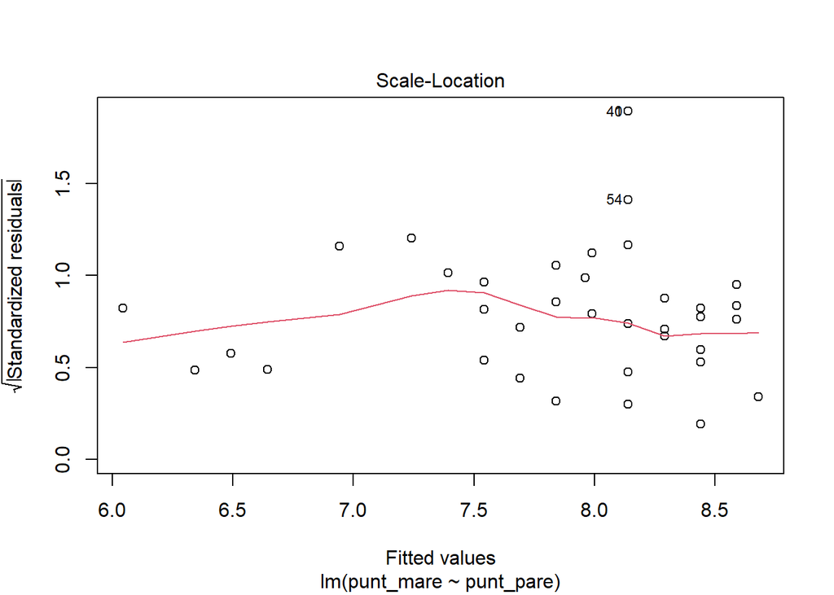

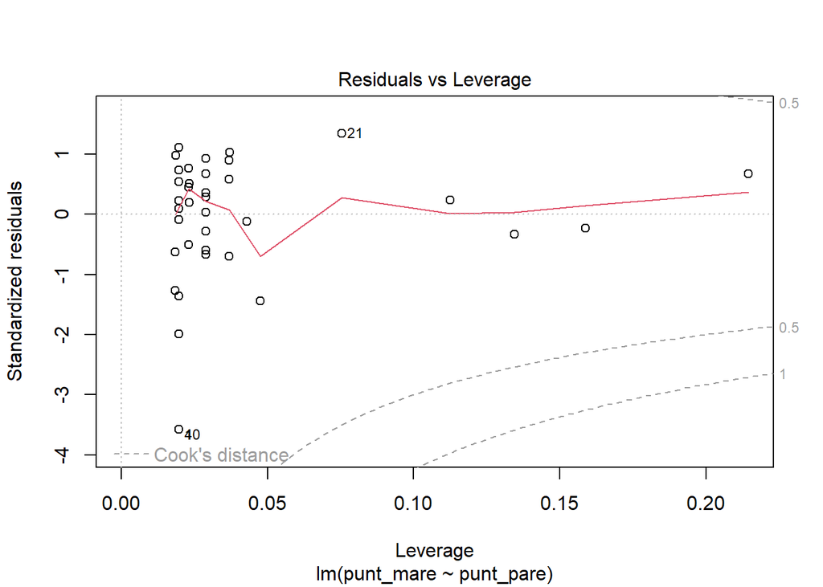

```r
plot(model_pares)
```

**10. Volem saber el d’alumnes que es porta almenys amb un 7 amb els seus dos pares**

Primer filtrem la base de dades per veure quins alumnes ho compleixen.

```r
data10 <- subset(data, punt_pare>=7 & punt_mare>=7); data10
```

```
## # A tibble: 36 × 15
##       ID Curs    sexe  altura polze index   mig anular menut punt_pare punt_mare
##    <dbl> <fct>   <fct>  <dbl> <dbl> <dbl> <dbl>  <dbl> <dbl>     <dbl>     <dbl>
##  1     8 2021-22 h        169   6     8.8  10      9.5   7.5       7.4       9.5
##  2     9 2021-22 d        169   6.5   9.5  10.7   10     7.8       9         8
##  3    11 2021-22 h        180   7.6  10.1  11.1   10.5   8.5       8.5       9
##  4    12 2021-22 h        175   6.5   9.5  10.8    9.6   8.2       9         9
##  5    14 2021-22 h        180   7.1   9.6  10.7   10.7   8.7       8         9
##  6    16 2021-22 d        167   5.7   9     9.7    9.1   7.3       9         9
##  7    18 2021-22 d        173   5.5   8.2   8.9    8.3   6.7       8.5       9.5
##  8    20 2021-22 d        168   5.6   7.9   9      8     6         9         9.5
##  9    22 2021-22 h        179   6.5   8.6   9.4    8.8   6.5       9.5       9.5
## 10    25 2021-22 d        164   5.6   7.7   8.2    7     6.2       8.5       9
## # ℹ 26 more rows
## # ℹ 4 more variables: parella <fct>, punt_parella <dbl>,
## #   sensacio_periode_covid <dbl>, ratio_2D4D <dbl>
```

```r
nrow(data10)/nrow(data)
```

```
## [1] 0.6428571
```

Aproximadament un $64.29\%$ dels alumnes, tenen una bona relació ($\geq 7$) amb el pare i amb la mare.

**11. Fem una taula de contingència per saber el nombre de persones amb parella o segons el sexe. Qui dels dos té un percentatge de parelles superior?**

```r
taula <- table(data$sexe, data$parella)
addmargins(taula)
```

```
##
##       no si Sum
##   d   10 17  27
##   h   14 13  27
##   Sum 24 30  54
```

```r
# Proporcions
prop.table(taula, margin=1)*100
```

```
##
##           no       si
##   d 37.03704 62.96296
##   h 51.85185 48.14815
```

Segons les dades, tenen parella un $62.96\%$ de les dones i un $48.15\%$ dels homes. En aquesta mostra, el sexe femení té un percentatge de parelles superior.

**12. Ajustem un model de Regressió Logística per determinar la mateixa associació que en l’apartat anterior. Calculem les probabilitats predites pel model i els intervals de confiança del 95% amb la llibreria `emmeans`.**

```r
library(emmeans)

model_log1 <- glm(parella ~ sexe, data = data, family = binomial)

# Probabilitats
prediccions <- emmeans(model_log1, ~ sexe, type = "response")
print(prediccions)
```

```
##  sexe  prob     SE  df asymp.LCL asymp.UCL
##  d    0.630 0.0929 Inf     0.438     0.788
##  h    0.481 0.0962 Inf     0.304     0.664
##
## Confidence level used: 0.95
## Intervals are back-transformed from the logit scale
```

**13. Ajustem el mateix model de l’apartat anterior però ara covariant segons la ratio dels dits. Tornem a calcular les probabilitats predites (ajustades o covariades).**

```r
model_log2 <- glm(parella ~ sexe + ratio_2D4D, data = data, family = binomial)

# Probabilitats
prediccions_ajustades <- emmeans(model_log2, ~ sexe, type = "response")
print(prediccions_ajustades)
```

```
##  sexe  prob     SE  df asymp.LCL asymp.UCL
##  d    0.632 0.0930 Inf     0.439     0.790
##  h    0.479 0.0965 Inf     0.301     0.663
##
## Confidence level used: 0.95
## Intervals are back-transformed from the logit scale
```

Mirem la significancia de les variables

```r
summary(model_log2)
```

```
##
## Call:
## glm(formula = parella ~ sexe + ratio_2D4D, family = binomial,
##     data = data)
##
## Coefficients:
##             Estimate Std. Error z value Pr(>|z|)
## (Intercept)   2.7334     4.2200   0.648    0.517
## sexeh        -0.6225     0.5571  -1.118    0.264
## ratio_2D4D   -2.2155     4.2213  -0.525    0.600
##
## (Dispersion parameter for binomial family taken to be 1)
##
##     Null deviance: 74.192  on 53  degrees of freedom
## Residual deviance: 72.710  on 51  degrees of freedom
##   (2 observations deleted due to missingness)
## AIC: 78.71
##
## Number of Fisher Scoring iterations: 4
```

El p-valor associat a la variable `ratio_2D4D` és aproximadament $0.6$. Com que és molt superior a $0.05$, podem concloure que la ràtio dels dits no és significativa per explicar si una persona té parella o no en aquesta mostra

Calculem el VIF per detectar multicolinealitat

```r
library(car)
vif(model_log2)
```

```
##       sexe ratio_2D4D
##    1.00516    1.00516
```

El VIF per a les variables és molt proper a 1. Un valor inferior a 5 indica que no hi ha problemes de multicolinealitat.

Des d’un punt de vista tècnic, el model és acceptable perquè no viola supòsits de colinealitat (VIF baix), però des d’un punt de vista pràctic és un model feble, ja que cap de les variables és un predictor realment fort de l’estat civil en aquest conjunt de dades

**14. Fem un model d’interacció per saber com es porten nois o noies amb cada pare. Fem una comparació 2 a 2.**

Per fer un model d’interacció, necessitem que cada puntuació sigui una observació independent, amb una variable que indiqui si es refereix al pare o a la mare.

```r
library(tidyr)
data_llarga <- data %>%
  pivot_longer(
    cols = c(punt_pare, punt_mare),
    names_to = "progenitor",
    values_to = "puntuacio"
  )
```

Ajustem el model per saber si la relació amb el pare/mare depèn del sexe de l’alumne

```r
model_interaccio <- lm(puntuacio ~ sexe * progenitor, data = data_llarga)
summary(model_interaccio)
```

```
##
## Call:
## lm(formula = puntuacio ~ sexe * progenitor, data = data_llarga)
##
## Residuals:
##     Min      1Q  Median      3Q     Max
## -6.0500 -0.6573  0.5077  1.3069  2.4500
##
## Coefficients:
##                           Estimate Std. Error t value Pr(>|t|)
## (Intercept)                 8.2778     0.3502  23.635   <2e-16 ***
## sexeh                      -0.5847     0.4867  -1.201    0.232
## progenitorpunt_pare        -0.2855     0.5001  -0.571    0.569
## sexeh:progenitorpunt_pare  -0.3576     0.6947  -0.515    0.608
## ---
## Signif. codes:  0 '***' 0.001 '**' 0.01 '*' 0.05 '.' 0.1 ' ' 1
##
## Residual standard error: 1.82 on 106 degrees of freedom
##   (2 observations deleted due to missingness)
## Multiple R-squared:  0.06113,    Adjusted R-squared:  0.03455
## F-statistic:   2.3 on 3 and 106 DF,  p-value: 0.08148
```

Fem comparacions 2 a 2 amb `emmeans`

```r
emmeans(model_interaccio, pairwise ~ progenitor | sexe, type = "response")
```

```
## $emmeans
## sexe = d:
##  progenitor emmean    SE  df lower.CL upper.CL
##  punt_mare    8.28 0.350 106     7.58     8.97
##  punt_pare    7.99 0.357 106     7.28     8.70
##
## sexe = h:
##  progenitor emmean    SE  df lower.CL upper.CL
##  punt_mare    7.69 0.338 106     7.02     8.36
##  punt_pare    7.05 0.344 106     6.37     7.73
##
## Confidence level used: 0.95
##
## $contrasts
## sexe = d:
##  contrast              estimate    SE  df t.ratio p.value
##  punt_mare - punt_pare    0.285 0.500 106   0.571  0.5693
##
## sexe = h:
##  contrast              estimate    SE  df t.ratio p.value
##  punt_mare - punt_pare    0.643 0.482 106   1.334  0.1851
```

Les noies (`d`) tenen, de mitjana, una puntuació de 8.28 amb la mare i 7.99 amb el pare. En canvi, els nois (`h`) tenen una mitjana de 7.69 amb la mare i 7.05 amb el pare

S’observa que les noies tendeixen a puntuar més alt la relació amb ambdós progenitors en comparació amb els nois.

Tant nois com noies tendeixen a puntuar millor la relació amb la mare que amb el pare, tot i que aquesta diferència és més forta en els nois (una diferència de $0.64$ punts) que en les noies ($0.28$ punts).

El p-valor de la interacció ($p = 0.608$) no és significatiu. Això indica que, tot i que les mitjanes canvien, el “patró” de relació (estimar més la mare que el pare) és similar en ambdós sexes i no hi ha una evidència estadística forta que els nois es portin “especialment” millor o pitjor amb un progenitor concret de forma diferent a les noies.

# QÜESTIÓ 2

**1. Fem un histograma de la variable alçada.**

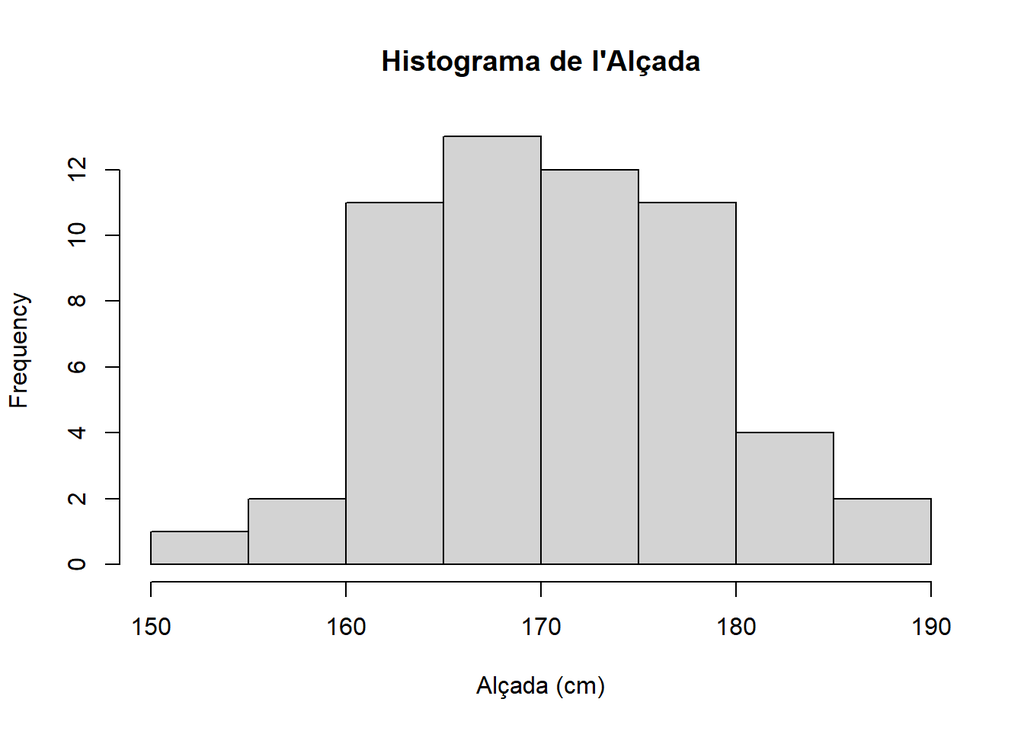

```r
hist(data$altura, breaks=10, main = "Histograma de l'Alçada", xlab = "Alçada (cm)")
```

```r
mu=mean(data$altura);mu
```

```
## [1] 171.8929
```

```r
sigma=sd(data$altura);sigma
```

```
## [1] 7.62455
```

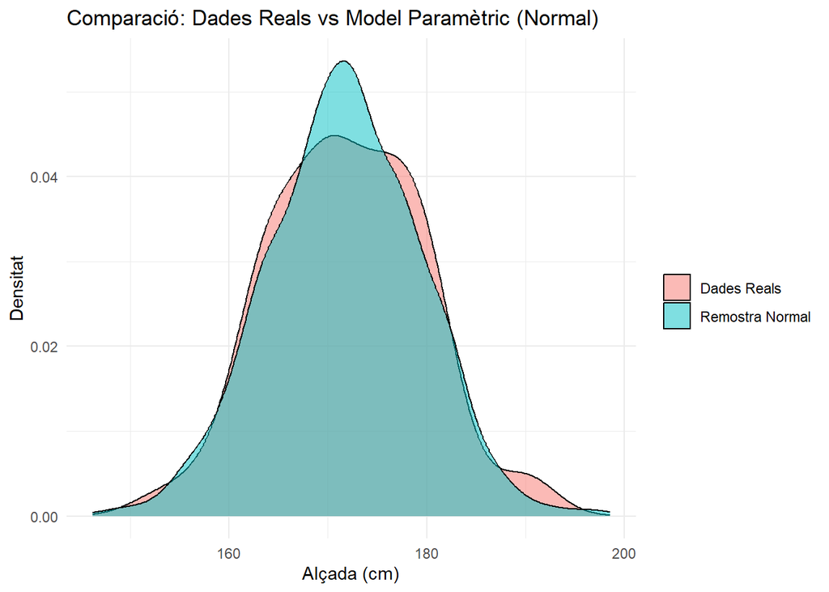

```r
set.seed(42)
remostra_param=rnorm(1000, mean = mu, sd = sigma)

#Comparació:

df_comp <- data.frame(
  valor = c(data$altura, remostra_param),
  origen = c(rep("Dades Reals", length(data$altura)),
             rep("Remostra Normal", 1000)))
library(ggplot2)
ggplot(df_comp, aes(x = valor, fill = origen)) +
  geom_density(alpha = 0.5) +
  labs(title = "Comparació: Dades Reals vs Model Paramètric (Normal)",
       x = "Alçada (cm)", y = "Densitat", fill = "") +
  theme_minimal()
```

Al ser la distribució Normal, aquesta pot generar valors extrems, inclús valors negatius, cosa que en una alçada no té sentit, a més, no captura bé les asimetries o outliers de la mostra real.

Es per això, que seria més òptim, utilitzar Bootstrap o una remostra no paramétrica, també seria una bona opció, una distribució que permeti la assimetria.

**2. Definició d’estrategia.**

Per saber si una persona té parella o no, podriem considerar la Bernoulli o la binomial per a n intents. Això ho hauriem de bassar en la proporció de la mostra.

Per tant, s’hauria de calcular la probabilitat de tenir parella a la mostra, i posteriorment generar valors aleatoris on cada observació té una probabilitat p de tenir parella:

```r
p=length(which(data$parella=="si"))
p=p/length(data$ID);p
```

```
## [1] 0.5357143
```

```r
remostra_parella <- sample(c("si", "no"), size = 1000, replace = TRUE,prob = c(p, 1 - p))

print(table(remostra_parella))
```

```
## remostra_parella
##  no  si
## 472 528
```

**3. Definició model multivariant.**

Com que els dits estan altament correlacionats, ja que formen part de la mà, i si aquesta és gran, els dits també ho son, s’ha optat per una distribució Normal Multivariant.

Model: Es calcula un vector de mitjanes dels 5 i la seva matriu de variancies covariancies.

Posteriorment es generen 1000 noves observacions que mantenen les característiques mitjanes dels dits i a més les seves correlacions.

```r
library(MASS)

dits=data[,5:9]
mu_dits=colMeans(dits);mu_dits
```

```
##    polze    index      mig   anular    menut
## 6.039286 8.142857 9.033929 8.283929 6.616071
```

```r
cov_dits= cov(dits);cov_dits
```

```
##            polze     index       mig    anular     menut
## polze  0.3082468 0.3130130 0.3682792 0.3546429 0.2551753
## index  0.3130130 0.8257662 0.9005195 0.8745195 0.6162078
## mig    0.3682792 0.9005195 1.0993734 1.0811006 0.7599903
## anular 0.3546429 0.8745195 1.0811006 1.2035552 0.8209903
## menut  0.2551753 0.6162078 0.7599903 0.8209903 0.6446461
```

```r
remostra_multi=as.data.frame(mvrnorm(n = 1000,
mu = mu_dits,Sigma = cov_dits))

colnames(remostra_multi)=dits

cat("\nPrimeres files de la remuestra multivariada:\n")
```

```
##
## Primeres files de la remuestra multivariada:
```

```r
print(head(remostra_multi))
```

[output not shown]

[output cut: 20 more lines]

**4. Reeplaçament de les dades dels dits.**

```r
n=nrow(dits)
remostra_bootstrap=dits[sample(1:n, size = n, replace = TRUE), ]

#Primeres files:
print(head(remostra_bootstrap))
```

```
## # A tibble: 6 × 5
##   polze index   mig anular menut
##   <dbl> <dbl> <dbl>  <dbl> <dbl>
## 1   5.5   8.2   8.9    8.3   6.7
## 2   6.4   8.5   9.4    7.4   6.5
## 3   5.9   8.3   9.7    9.1   7.2
## 4   5.2   8     8.5    7.5   6
## 5   6.4   8.5   9.4    7.4   6.5
## 6   6     8.5   9.5    9     7
```

```r
#Comparació de mitjanes:
comp_means=rbind(
  Original  = round(colMeans(dits), 3),
  Bootstrap = round(colMeans(remostra_bootstrap), 3)
)

print(comp_means)
```

```
##           polze index   mig anular menut
## Original  6.039 8.143 9.034  8.284 6.616
## Bootstrap 5.979 8.118 9.030  8.257 6.593
```